# Avicenna ESM Compliance Monitoring Tool

Robin Achterhof

31 March 2026

# About this ESM Compliance Monitoring Tool

This document is a beginner-friendly template for monitoring Experience Sampling Method (ESM) compliance in studies that use **Avicenna** to collect data. It allows you to:

- **track compliance** while your ESM study is running
- include **one or multiple** different Avicenna questionnaires
- perform **automatic checks** on things that may be going wrong
- do all this **dynamically**, getting you quick updates while additional data is coming in
- test everything using a built-in **demo dataset**

When you knit this document in R Markdown (`Ctrl+Shift+K`), it will give you a nice overview of common issues, compliance rates and visualizations. And if you want, the script can also generate an Excel file with participant‑level compliance (and optional payment information).

Of course, it is very well possible that there are some mistakes in this template. If you encounter any, please do let me know at achterhof@essb.eur.nl.

**Acknowledgements:** This entire tool is inspired by the ESM compliance management tools developed by Anne Buelow, developed for the [100 Days Of My Life](https://osf.io/a9g7c/overview) study, and the [PARADOX](https://osf.io/mwpt7/files/m2qwh) study. These tools were intended to use only for those studies, and have not been published. In addition, generative AI has been used to help draft and hone the code throughout this script.

**To use this template:**

1. Place this .Rmd file in a folder of your choice
2. Create a subfolder named `/data`, and place your Avicenna `.csv` file(s) in this folder. The script will automatically detect and load the newest file, and archive any older files into `/old`
3. Always update the study settings in the first code chunk below.
4. Enable optional modules (ID matching, extra plots, Excel export) in that same first code chunk.
5. Knit the document.

Note: This template assumes **standard Avicenna variable names**, including:

- `Participant.ID`
- `Session.Scheduled.Time`
- `Prompt.Time`
- `Record.Time`
- `Status`

If your file uses different names, you must rename them before using this template.

If you have any questions about Avicenna data, please also take a look at the help available on https://forum.avicennaresearch.com/

# 1. User Inputs

This first section contains the **only settings you need to modify**: Information about days and number of beeps, a demo dataset to test this script with, and some toggles that allow you to use multiple Avicenna files, merge this file with an external file of participant ID’s, add extra visualizations, and create an Excel export with relevant information.

## Study settings (required)

These settings can be adapted during the study, reflecting the current moment in the study[^1]. When the study has ended completely, you can just enter the last day of the study, and the last prompt of the day.

```r
# Folder where data is stored
data_path <- "data"

# Core study settings
# Note: if use_demo_dataset = TRUE, the demo is generated using these values.
# Adjust them to reflect the study you want to simulate.
study_day       <- 5
current_beep  <- 3
beeps_per_day   <- 10
start_date      <- as.Date("2026-02-28")
```

## Demo mode (quick start)

If you want to try this template without your own data, enable the demo dataset here. If you want, you can also adjust the number of participants, days, and beeps per day in these simulated data.

```r
use_demo_dataset <- TRUE
# Demo dataset settings (only used when use_demo_dataset = TRUE)
demo_n_participants <- 30
demo_n_days        <- study_day        # mirrors your study settings
demo_beeps_per_day <- beeps_per_day    # mirrors your study settings
```

> **Using the demo?** Make sure the study settings above (`study_day`, `beeps_per_day`, `start_date`) reflect the study you want to simulate — the demo dataset is generated based on those values. The defaults are a good starting point. Set `use_demo_dataset <- FALSE` when you are ready to use your own data.

## Optional Modules (simple toggles)

**About the toggles:** These settings work like on/off switches, controlling whether optional modules in the template are executed.

Set a toggle to TRUE to activate a module. If you are unsure, leave everything on FALSE.

`use_plots` and `use_quality_indicators` default to TRUE but can be set to FALSE if you want to knit quickly — for example, when you just want a compliance summary without waiting for plots or item-level quality calculations to run.

```r
use_multiple_files     <- FALSE   # Merge multiple Avicenna Activities
use_excel_export       <- TRUE   # Export compliance to Excel
use_external_ids       <- FALSE   # Merge external participant IDs (requires external_ids.xlsx)
use_remuneration       <- TRUE   # Add payment calculations to Excel
use_plots              <- TRUE    # Generate compliance visualizations (Section 6)
use_quality_indicators <- TRUE    # Compute data quality indicators (Section 7.1)
```

## Advanced Settings (only relevant if toggles above are TRUE)

### Multiple Avicenna files

Only needed if `use_multiple_files = TRUE`.

```r
activity_ids <- c(27337, 28137, 28138)   # e.g., c(27337, 28137, 28138)
```

**About the multiple files:** You only need to use this setting if you want to merge different data sets that you export from Avicenna (otherwise, you can just leave it blank). Each Avicenna questionnaire (“Activity”) has a unique 5‑digit ID. If you have multiple questionnaires (e.g., morning, evening, weekend-only, weekly), simply add all their Activity IDs to activity_ids in the chunk above

You can find this ID in the file name of your export, e.g.: `study-4882-export-166-survey-responses-27337-2026-03-16-12-17-13.csv`.

Here, **27337** would be the Activity ID. This number corresponds with the number you can find next to each separate questionnaire in the Avicenna dashboard.

### External IDs

Only needed if `use_external_ids = TRUE`.

**About the external ID’s:** If you want to link Avicenna participant IDs to your own (different) participant codes, set `use_external_ids = TRUE` and create a file named `external_ids.xlsx` with the columns `Participant.ID` (representing the Avicenna ID) and `External.ID` (representing the participant ID you want to link). Place this file in the same folder as this .Rmd file.

### Remuneration

Only needed if `use_remuneration = TRUE`.

**About remuneration**: Some studies pay participants **per completed beep** (e.g., €0.50 per completed prompt), or a different amount when a certain **threshold** is reached (e.g., €20 euros when compliance <80%, but €30 when compliance >80%). This script allows for automatically calculating either of these options.

To enable remuneration:

1. Set `use_remuneration = TRUE`
2. Choose a payment mode (`per_beep` or `threshold`)
3. Adjust the corresponding payment values to your design

```r
payment_mode <- "per_beep"   # "per_beep" or "threshold"

payment_per_beep <- 0.50     # Used when payment_mode = "per_beep"

# Threshold payment structure:
# Names = compliance thresholds (0–1), values = payment amounts
payment_thresholds <- c(
  "0.80" = 30,   # If compliance >= 80% → €30
  "0.00" = 20    # Otherwise → €20
)
```

### Data quality indicators

Only needed if `use_quality_indicators = TRUE`.

**About data quality indicators:** This module computes several simple checks that help you evaluate whether participants responded carefully and plausibly. These checks are based on responses that are too quick, or too similar to each other, and they require item‑level response data (VAS or SAQ items) to be present in your dataset.

Note that these indicators are not proof of careless responding — they are simply signals that may warrant closer inspection. Interpretation should always consider the study context and the participant’s overall pattern.

The only adjustable setting here is the minimum amount of time *per item* that you estimate people need to reliably complete it. The default of 0.5 second per item is somewhat arbitrary.

```r
# Minimum plausible seconds per questionnaire item.
# A completed beep is flagged as suspiciously fast if:
#   response time (seconds) < n_items * min_seconds_per_item
# You can increase this threshold if your items require more reading time.
min_seconds_per_item <- 0.5
```

# 2. Folder Setup

This section:

- Creates required folders
- Moves old files to /old
- Checks that required Avicenna columns exist
- Warns about missing or invalid data

```r
knitr::opts_chunk$set(echo = FALSE, warning = FALSE, message = FALSE)
```

# 3. Load data

If you exported **one Avicenna file**, the script will automatically load the newest .csv file in the /data folder.

If you exported **multiple Avicenna files** (i.e., different Activities), set `use_multiple_files = TRUE` and enter the Activity IDs in the User Inputs section in the first chunk.

If you set `use_demo_dataset = TRUE`, the code will create some simulated data for you.

# 4. Sanity checks

This section checks whether your dataset contains the required Avicenna variables and whether timestamps and dates look correct. If something is wrong, the script will warn you and tell you what to fix.

**About the warnings below:** If something in your dataset looks unusual, this section will show a coloured message box. These warnings do *not* stop the document from knitting — they simply highlight issues that may affect your compliance calculations (for example: missing timestamps, unexpected Status values, or dates that don’t match your study setup).

The coloured boxes are meant to be highly visible, so you can quickly spot potential problems without having to read through R warnings or code output.

Also, **a note on time zones**: Avicenna stores all timestamps internally in **UTC**. When exporting to CSV, Avicenna converts timestamps to local time — but depending on the device, DST rules, or the moment of export, this conversion may differ slightly from what you see in the dashboard.

This can lead to:

- Some participants appearing to have prompts 1 hour earlier or later
- Slight differences between the dashboard and the CSV
- Apparent inconsistencies between participants

This is normal and does not affect the actual scheduling logic. For more details, see Avicenna’s explanation: https://forum.avicennaresearch.com/t/participation-period/1279#p-2906-time-zone-12

**✔ All checks passed.** No issues detected in your dataset.

# 5. Compliance calculation

## A brief note on understanding compliance in Avicenna data

Each ESM prompt in Avicenna receives a Status code. These codes tell us what happened to each beep:

- Unanswered/Unknown (ID 0) indicates that a response to this particular session hasn’t been registered or uploaded yet. This status doesn’t necessarily mean the session hasn’t been initiated; it might have been prompted, but the response is yet to be recorded.
- Completed (ID 1) indicates the participant completed the session and submitted it.
- Canceled (ID 2) indicates the participant did not want to complete the session and explicitly canceled it.
- Expired (ID 3) indicates the session was not responded to in time, so Avicenna automatically marked the session as expired.
- Blocked (ID 4) indicates the session was blocked by another active session from the same Activity and could not be prompted.
- Other (ID 5) indicates something else going on
- In Progress (ID 6) indicates the session is started by the participant but it’s not completed, canceled, or expired yet.

Whilst running an ESM study in Avicenna, you may notice a lot of “0” (unknown/unanswered) responses. This does not mean that these responses will never come - it simply reflects the fact that the Avicenna server needs to connect to participants’ phones to retrieve their data. You can expedite this process by asking participants to reload their app, or by manually reloading participants yourself, in the Participation tab in the Avicenna dashboard.

Now, in this template, we calculate **three different indicators** to help you understand where your study is at:

- **Completed compliance**: This is a strict definition: Only `Status = 1` counts as a completed beep. Everything else counts as “not completed”.
- **Full status breakdown**: You will also get a breakdown of these different status categories. This helps you understand why compliance may be low (is it because people really did not answer your prompts, or because their responses have just not yet come through?)
- **Synchronization completeness**: the variable `fully_synced` tells you, for each participant, whether they are fully synced. A participant will get the value `1` for this variable if **every ESM prompt** has come through. If there is at least one prompt that’s still in the air somewhere, a participant will get a value `0` for this variable.

The values below give you a quick overview of how compliant your sample is. They are often the first numbers you want to check during a study.

Compliance summary across all participants

[output not shown]

# 6. Plots

These visualizations help you quickly understand how your sample is responding.

They mostly reflect compliance, based on the description in the compliance calculation above, but also give some insight into the different statuses and mean response times.

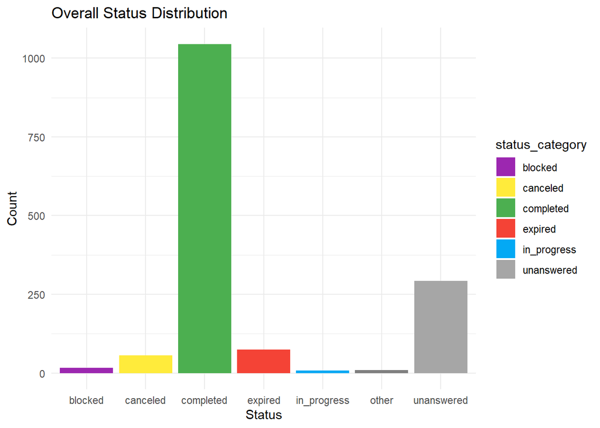

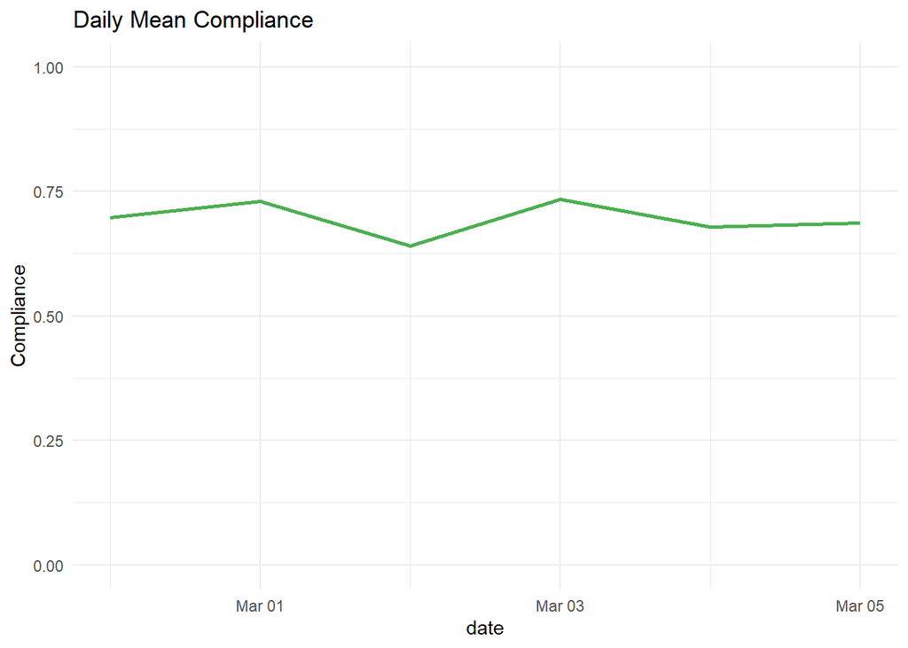

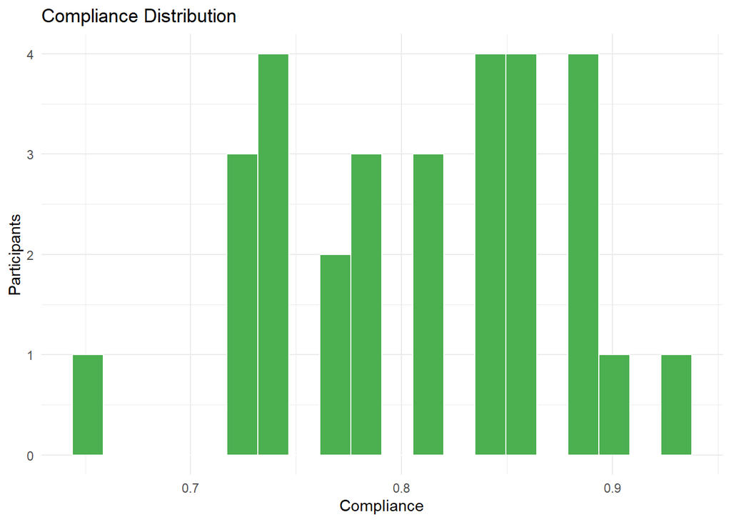

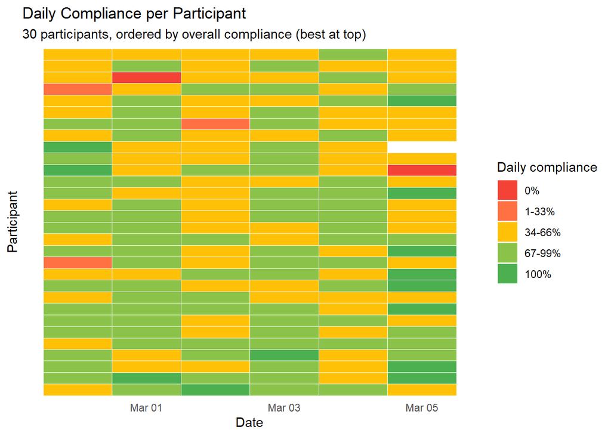

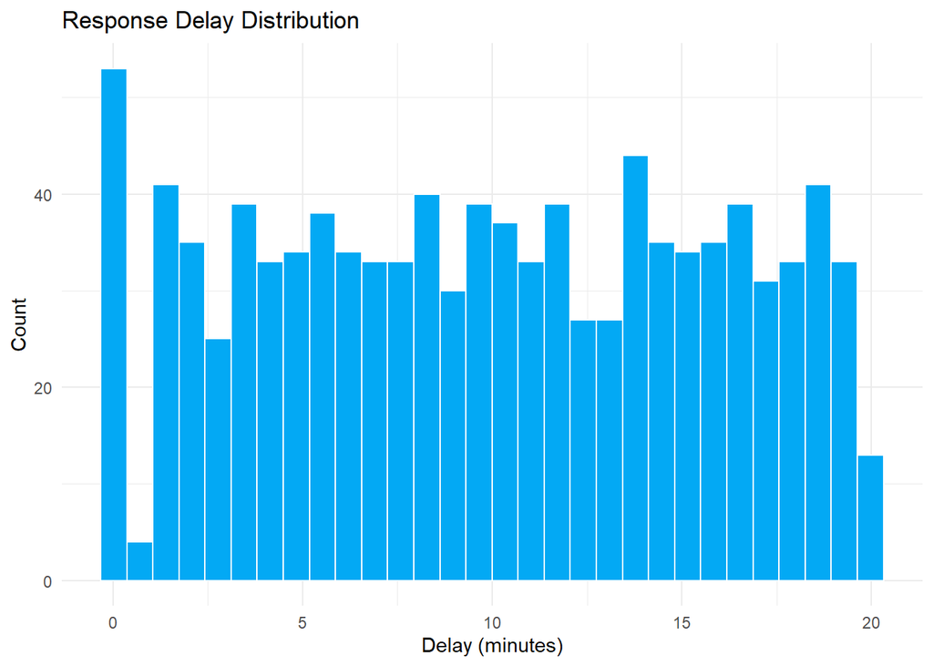

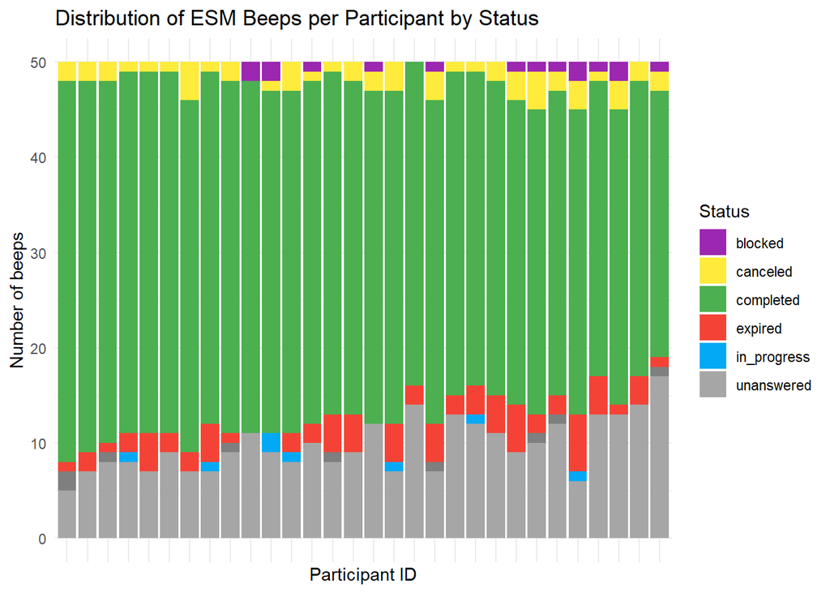

# 7. Optional Modules

These sections only run if you set the corresponding toggle to TRUE in the User Inputs section.

They allow you to:

- Compute data quality indicators (fast completions, within-beep SD, longstring)
- Link external participant IDs
- Export participant IDs and compliance to Excel

`use_plots` and `use_quality_indicators` are controlled from the toggles chunk and default to TRUE. Set them to FALSE for faster knitting when you only need compliance numbers.

## 7.1 Data Quality Indicators

### Quality indicators

These are computed only for **completed beeps** with item-level response data present.

- **Longstring** *(SAQ items only)* — the percentage of SAQ items within a beep that share the same value (the beep-level mode). A high longstring score means the participant largely selected the same response option across all items, a classic indicator of careless responding on Likert scales. Computed only when SAQ columns are detected.
- **Within-beep SD** *(VAS items only)* — the standard deviation of responses across all VAS items within a single beep. A very low SD means the participant gave near-identical ratings to all items, which may indicate repetitive or inattentive responding. Computed only when VAS columns are detected.

**A note on interpretation:** These indicators are proxies, not proof of carelessness. Very low within-beep SD on VAS items could reflect genuine low affect variability. High longstring on SAQ items could reflect a genuinely homogeneous emotional state. Both are worth flagging and inspecting, but should be interpreted in the context of the study and the participant’s overall pattern. For a discussion of the limitations of these indicators, see Eisele et al. (2026) and Pihlajamäki et al. (2025).

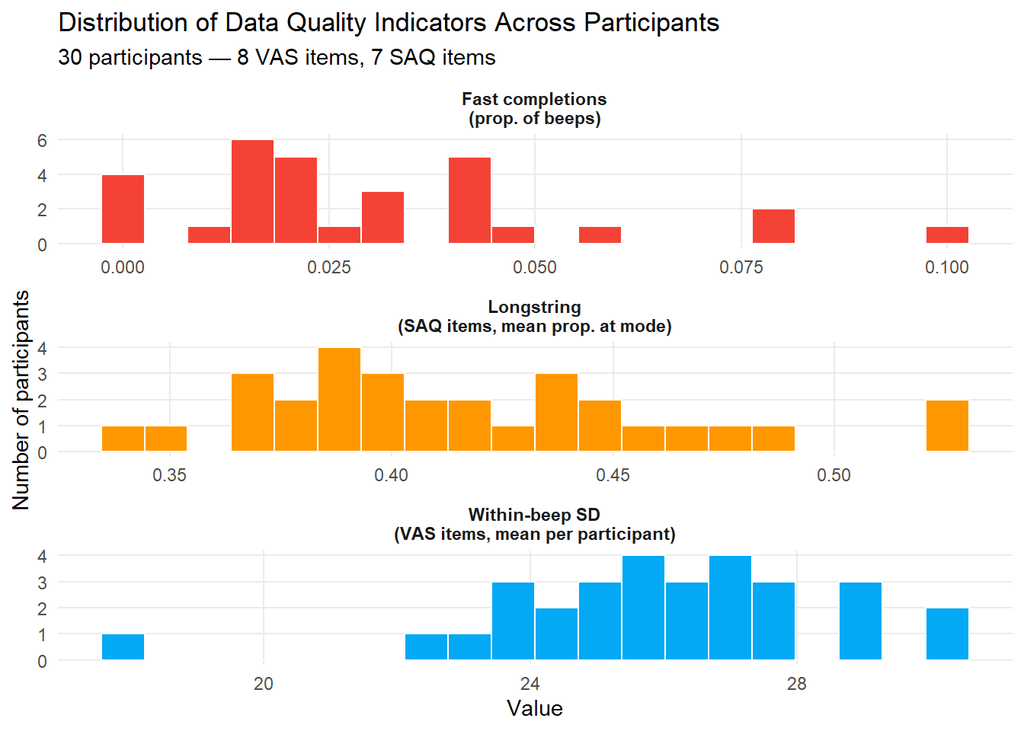

*Each histogram shows the distribution of a quality indicator across participants. Participants appearing at the extremes of these distributions may warrant closer inspection. No threshold is applied — use your knowledge of the study to judge what is noteworthy.*

**⚠ Suspiciously fast completions detected.**  
**53** completed beep(s) across **26** participant(s) had a response time below the threshold (*15 items × 0.5 s = 7.5 s*).  
This does not necessarily mean fraud — participants may have skipped through items, or there may be a timestamp recording issue. Please review the cases below.

**Participants with at least one suspiciously fast completion:**

| Participant ID | Fast completions (n) | Median delay (s) | Fastest delay (s) |
| --- | --- | --- | --- |
| 10 | 5 | 4.7 | 3.8 |
| 5 | 4 | 3.8 | 3.2 |
| 7 | 4 | 4.9 | 1.9 |
| 2 | 3 | 4.7 | 2.1 |
| 14 | 3 | 3.5 | 2.9 |
| 26 | 3 | 2.2 | 1.3 |
| 1 | 2 | 2.6 | 1.2 |
| 6 | 2 | 3.9 | 2.8 |
| 11 | 2 | 2.3 | 1.8 |
| 12 | 2 | 5.3 | 4.2 |
| 13 | 2 | 3.3 | 3.0 |
| 16 | 2 | 5.7 | 5.5 |
| 21 | 2 | 3.1 | 2.9 |
| 22 | 2 | 3.6 | 1.9 |
| 23 | 2 | 4.4 | 3.8 |
| 27 | 2 | 2.4 | 1.5 |
| 30 | 2 | 4.6 | 3.0 |
| 4 | 1 | 2.2 | 2.2 |
| 8 | 1 | 3.4 | 3.4 |
| 9 | 1 | 2.4 | 2.4 |
| 15 | 1 | 4.0 | 4.0 |
| 17 | 1 | 4.7 | 4.7 |
| 18 | 1 | 4.7 | 4.7 |
| 19 | 1 | 1.6 | 1.6 |
| 24 | 1 | 3.6 | 3.6 |
| 28 | 1 | 6.4 | 6.4 |

## 7.2 External ID Matching

Sometimes the participant IDs used in Avicenna (the Participant.ID column) are not the same IDs you use in your own study administration — for example:

- You assigned your own participant numbers
- You use anonymized codes
- You have a separate payment or contact list
- You want to merge demographic or baseline questionnaire data

This optional module allows you to link Avicenna IDs to your own external IDs.

To use it:

- Create a file named `external_ids.xlsx`
- Place it in the same folder as this `.Rmd` file
- Make sure it contains **at least** the following two columns:

#### Example structure of `external_ids.xlsx`:

```
Participant.ID,External.ID
145812,PP001
146889,PP002
147001,PP003
```

If you enable `use_external_ids = TRUE` in the first chunk, the script will automatically merge these IDs into your compliance table.

## 7.3 Excel Export

This module creates a clean Excel file containing:

- **Compliance sheet**: Participant ID, total beeps, number of completed beeps, compliance proportion, sync status, rank, and quality indicator scores (`pct_fast`, `mean_vas_sd` if VAS items detected, `mean_longstring` if SAQ items detected)
- **Payments sheet** *(optional, if `use_remuneration = TRUE`)*: Participant ID, compliance, calculated payment
- **Flagged sheet** *(only if suspiciously fast completions were detected)*: All flagged rows with response times and thresholds
[^1]: It may be that you are in the middle of a current response window. It is recommended that you always refer to the last fully elapsed beep, to not underestimate compliance too much
[^2]: Eisele, G., Achterhof, R., Lachowicz, A. M., De Calheiros Velozo, J., Vaessen, T., Peeters, L., & Myin-Germeys, I. (2026). The distracted participant? Experience sampling response behavior and participant disturbance in social situations. *Psychological Assessment*. https://doi.org/10.1037/pas0001463